Suche nach:

[figure not shown]

# Knusper, knusper knäuschen … – 50 Jahre Hänsel und Gretel

Veröffentlicht: 29. November 2022

Keine Kommentare

Tags: [Hänsel und Gretel](https://blog.staatsoper-hamburg.de/tag/haensel-und-gretel/), [Jubiläum](https://blog.staatsoper-hamburg.de/tag/jubilaeum/)

**Ab dem 27. November 2022 steht *Hänsel und Gretel* wieder auf dem Spielplan der Staatsoper Hamburg. In diesem Jahr feiert die Inszenierung von Peter Beauvais ein zauberhaftes 50-Jähriges Jubiläum. Für die Jubiläumsvorstellung am 6. Dezember 2022 suchte die Staatsoper Hamburg Zeitzeugen aus den letzten 50 Jahren, die selbst als Kind *Hänsel und Gretel* gesehen haben. Sie erzählten uns ihre schönsten Erinnerungen und Geschichten, die sie mit der märchenhaften Oper erleben durften. Viel Spaß bei unserer kleinen Zeitreise durch *Hänsel und Gretel*!**

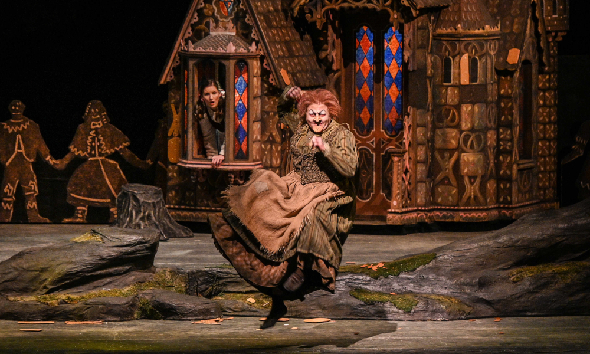

Kammersänger Peter Galliard als Knusperhexe, hinten: Elsa Benoit als Gretel  
Foto: Hans Jörg Michel

„An der Oper „Hänsel und Gretel“ in Hamburg haben wir uns schon seit drei Generationen erfreut: Großmutter, Tochter und Enkelin! Nicht nur war es die erste Oper, die ich, als Kind gesehen habe, sondern auch die erste, bei der ich mit den Hamburger Alsterspatzen als Lebkuchenkind mit auf der Bühne stehen durfte. Abgesehen vom eigentlichen Auftritt habe ich mich damals immer besonders auf den Flug der Hexe gefreut, den wir von hinter der Bühne beobachten konnten sowie den Sturm auf das Lebkuchenhaus, sobald der Vorhang geschlossen war, um einen der (echten!) Lebkuchen, die daran klebten, zu ergattern. Das alles war natürlich eine unheimlich aufregende Erfahrung und ich erinnere mich gerne daran zurück.“ – Anja H.-G., Heidrun Sibylle H. und Merle G.

„Der absolute Höhepunkt, das muss ich gestehen, war – die Hexe! Und natürlich die Szene, in der sie auf ihrem Besen über das Hexenhaus in den Himmel – oder war es die Hölle? – fliegt. Das wirkte so dermaßen echt. Keines von uns Kindern hat sich damals Gedanken über die Bühnentechnik gemacht! Wir, die wir noch nicht an „special effects“ aus Film und Fernsehen, geschweige denn aus Computerspielen gewöhnt waren, haben beinahe geglaubt, dass die Hexe wirklich fliegt!“ – Bettina W.

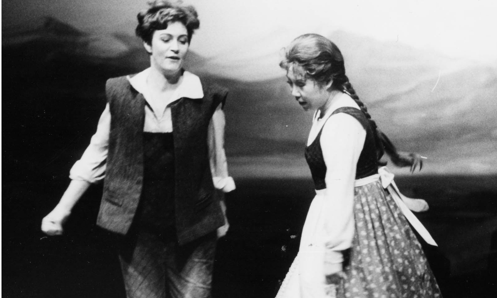

Hildegard Hartwig als Hänsel und als Gretel Kammersängerin Hellen Kwon  
Foto: LENA & Rolf Mönkedieck

„Es muss etwa 1982 gewesen sein, als ich zum Ersten Mal mit in die Oper genommen wurde. Ich war damals 7 Jahre alt und hatte von der Oper noch nie gehört. Gespielt wurde Hänsel und Gretel. Ich kannte natürlich das Märchen und freute mich sehr. Es war ein unglaublich schöner Abend. Ich war begeistert von der Musik und dem Gesang. Die Oper hat mich seitdem in ihren Bann gezogen und vor einigen Jahren, mittlerweile bin ich Mutter einer Tochter, habe ich eine ähnliche Aufregung gespürt wie an jenem Abend 1982. An jenem Abend bin ich mit meiner kleinen Tochter in ihre erste Oper gegangen … Hänsel und Gretel.“ – Larissa S.

„In meiner Kindheit habe ich mit meiner Oma häufig Theaterstücke, Konzerte und weitere Aufführungen für Kinder besucht. Diese Ausflüge mit meiner Oma haben meine Kindheit stark geprägt und ich erinnere mich gerne an diese Zeit zurück, auch wenn ich mich nicht mehr an alles detailliert erinnern kann. Unter anderen erinnere ich mich allerdings an das Stück Hänsel und Gretel zurück, welches wir uns in der Hamburger Staatsoper angesehen haben. Neben der beeindruckenden Kulisse der Staatsoper sind mir besonders die aufwendigen Bühnenbilder in Erinnerung geblieben.“ – Antonia K.

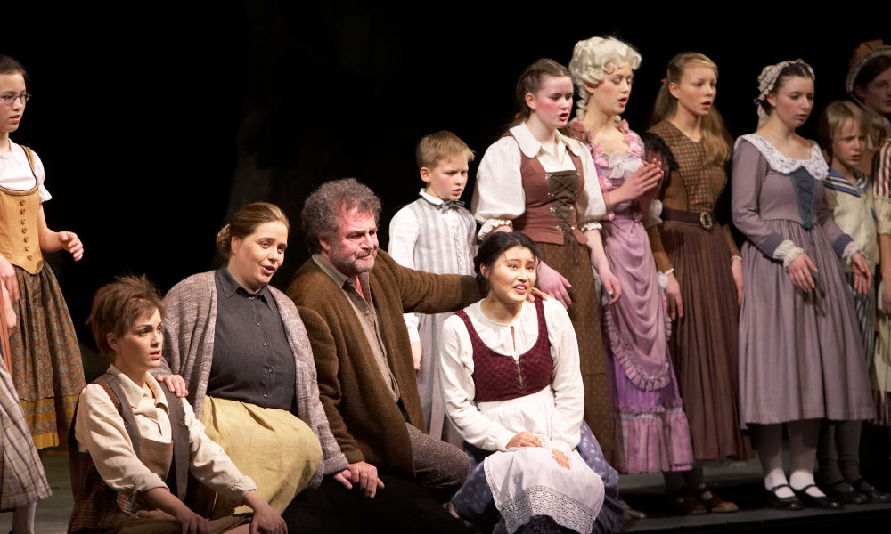

Hamburger Kammersänger und Ehrenmitglied der Hamburgischen Staatsoper Franz Grundheber als Peter mit Hänsel und Gretel. Bereits bei der Premiere stand er in dieser Partie auf der Bühne  
Foto: Brinkhoff/Mögenburg

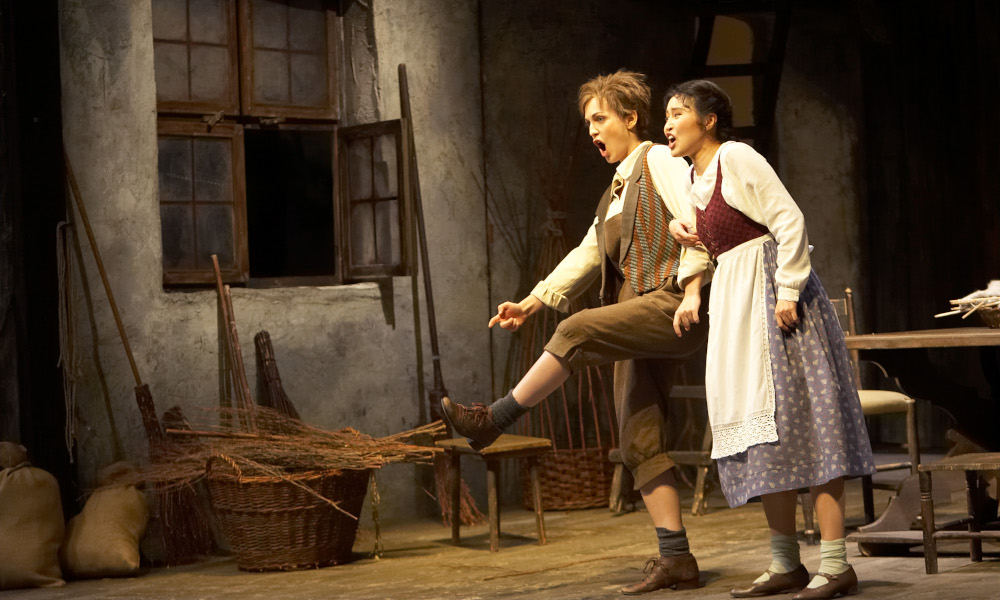

Seit Jahren ist das Märchen um das Geschwisterpaar fester Bestandteil der Weihnachtszeit  
Foto: Brinkhoff/Mögenburg

„1974/1975 spielte ich als 12 bzw. 13-jähriger das Hänsel-Double in der Traumszene im Wald am Ende des 2. Aktes. Was die Hauptdarstellerinnen Hänsel und Gretel vorn auf der Bühne träumten, erlebten die Kinder-Doppelgänger oben auf der Hebebühne real. Echt lecker: Eine übergroße Lebkuchen-Bretzel vom Stadtbäcker, die einer der 14 Engel in der Szene aus dem Rock zieht und dem Hänsel hinhält, der nach Zögern dann hungrig zugreift und herzhaft reinbeißt. Einer dieser „14 Engel“ – ein Mann von der Statisterie – schenkte mir die Gelegenheit, den zweiten Teil der Oper nach der Pause vom Zuschauerraum aus verfolgen zu können. Dank seiner internen Kenntnisse und Kontakte war es möglich, unauffällig durch die Kellergänge vom Bühnenhaus ins Haupthaus in den obersten Rang bei den Hörplätzen zu gelangen und die Aufführung von dort bis zum Schluss zu verfolgen.“ – Christian P.

Teilen

## Hänsel und Gretel

„Kennst du nicht den schauerlich düstern Ort, weißt nicht, dass die Böse dort wohnt?“: Überstürzt brechen die Eltern in den Wald auf, um Hänsel und Gretel vor der Knusperhexe Rosina Leckermaul zu retten. Wie befürchtet, haben sich die Kinder im Wald verirrt und sind auf das Lebkuchenhaus gestoßen. Sie können der süßen Verlockung nicht widerstehen - und tappen in die Falle der Hexe, die Kinder buchstäblich zum Fressen gern hat…

[Mehr …](https://www.staatsoper-hamburg.de/de/spielplan/stueck.php?AuffNr=183625)

[Voriger Beitrag](https://blog.staatsoper-hamburg.de/literarisch-musikalischer-adventskalender-2022/)

[Literarisch-Musikalischer Adventskalender 2022](https://blog.staatsoper-hamburg.de/literarisch-musikalischer-adventskalender-2022/)

[interactive chart not shown]